# Project Title: Predicting DVD Rental Duration for Inventory Optimization

A DVD rental company wants to predict how many days a customer will keep a DVD. Accurate predictions enable better inventory planning, reduce stock-outs, and improve customer satisfaction. *Success criterion*: Mean Squared Error (MSE) ≤ 3 on an unseen test set. *Target variable*: rental_length_days (derived from return date − rental date).

```python
# Importing necessary libraries
import pandas as pd
import numpy as np
import matplotlib.pyplot as plt
import seaborn as sns
from sklearn.model_selection import train_test_split
from sklearn.metrics import mean_squared_error, mean_absolute_error, r2_score
from sklearn.linear_model import LinearRegression, Ridge, Lasso
from sklearn.ensemble import RandomForestRegressor, GradientBoostingRegressor
from statsmodels.stats.outliers_influence import variance_inflation_factor
import warnings
warnings.filterwarnings('ignore')

pd.set_option('display.max_columns', None)
sns.set_style('whitegrid')
```

```python
#Load Data
df = pd.read_csv('rental_info.csv')
print(f"Shape: {df.shape}")
df.head()
```

```
Shape: (15861, 15)
```

|  | rental_date | return_date | amount | release_year | rental_rate | length | replacement_cost | special_features | NC-17 | PG | PG-13 | R | amount_2 | length_2 | rental_rate_2 |
| --- | --- | --- | --- | --- | --- | --- | --- | --- | --- | --- | --- | --- | --- | --- | --- |
| 0 | 2005-05-25 02:54:33+00:00 | 2005-05-28 23:40:33+00:00 | 2.99 | 2005.0 | 2.99 | 126.0 | 16.99 | {Trailers,"Behind the Scenes"} | 0 | 0 | 0 | 1 | 8.9401 | 15876.0 | 8.9401 |
| 1 | 2005-06-15 23:19:16+00:00 | 2005-06-18 19:24:16+00:00 | 2.99 | 2005.0 | 2.99 | 126.0 | 16.99 | {Trailers,"Behind the Scenes"} | 0 | 0 | 0 | 1 | 8.9401 | 15876.0 | 8.9401 |
| 2 | 2005-07-10 04:27:45+00:00 | 2005-07-17 10:11:45+00:00 | 2.99 | 2005.0 | 2.99 | 126.0 | 16.99 | {Trailers,"Behind the Scenes"} | 0 | 0 | 0 | 1 | 8.9401 | 15876.0 | 8.9401 |
| 3 | 2005-07-31 12:06:41+00:00 | 2005-08-02 14:30:41+00:00 | 2.99 | 2005.0 | 2.99 | 126.0 | 16.99 | {Trailers,"Behind the Scenes"} | 0 | 0 | 0 | 1 | 8.9401 | 15876.0 | 8.9401 |
| 4 | 2005-08-19 12:30:04+00:00 | 2005-08-23 13:35:04+00:00 | 2.99 | 2005.0 | 2.99 | 126.0 | 16.99 | {Trailers,"Behind the Scenes"} | 0 | 0 | 0 | 1 | 8.9401 | 15876.0 | 8.9401 |

```python
#Feature Engineering
df['rental_date'] = pd.to_datetime(df['rental_date'])
df['return_date'] = pd.to_datetime(df['return_date'])
df['rental_length_days'] = (df['return_date'] - df['rental_date']).dt.days
```

```python
df['deleted_scenes'] = df['special_features'].str.contains('Deleted Scenes').astype(int)
df['behind_the_scenes'] = df['special_features'].str.contains('Behind the Scenes').astype(int)
```

```python
#Exploratory Data Analysis
print(df['rental_length_days'].describe())
```

```
count    15861.000000
mean         4.525944
std          2.635108
min          0.000000
25%          2.000000
50%          5.000000
75%          7.000000
max          9.000000
Name: rental_length_days, dtype: float64
```

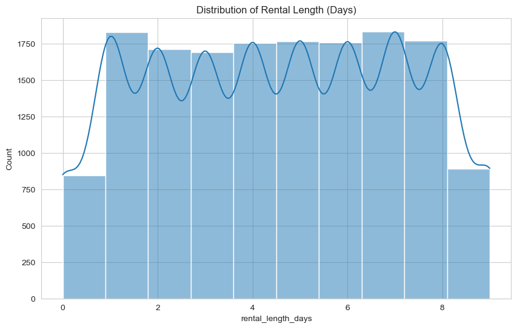

```python
# Distribution of target
plt.figure(figsize=(10,6))
sns.histplot(df['rental_length_days'], bins=10, kde=True)
plt.title('Distribution of Rental Length (Days)')
plt.show()
```

```python
# Correlation with target
feature_cols = [
    'amount', 'release_year', 'rental_rate', 'length', 'replacement_cost',
    'NC-17', 'PG', 'PG-13', 'R', 'amount_2', 'length_2', 'rental_rate_2',
    'deleted_scenes', 'behind_the_scenes'
]
corr = df[feature_cols + ['rental_length_days']].corr()['rental_length_days'].sort_values(ascending=False)
print(corr)
```

```
rental_length_days    1.000000
amount                0.551593
amount_2              0.549412
replacement_cost      0.015684
PG-13                 0.010201
release_year          0.007044
NC-17                 0.000783
behind_the_scenes    -0.000058
rental_rate          -0.001060
rental_rate_2        -0.001258
deleted_scenes       -0.002615
length               -0.004547
length_2             -0.004792
R                    -0.007961
PG                   -0.008066
Name: rental_length_days, dtype: float64
```

```python
#Assumption Checks & Diagnostics
# Multicollinearity (Variable Inflation Factors)
X = df[feature_cols]
vif = pd.DataFrame()
vif['Feature'] = X.columns
vif['VIF'] = [variance_inflation_factor(X.values, i) for i in range(X.shape[1])]
print(vif.sort_values('VIF', ascending=False))
```

```
              Feature         VIF
3              length  380.272264
10           length_2  143.987498
2         rental_rate  140.167380
1        release_year  107.723160
11      rental_rate_2   71.952293
0              amount   71.906212
9            amount_2   27.994850
4    replacement_cost   12.245484
7               PG-13    2.308108
5               NC-17    2.198471
13  behind_the_scenes    2.186198
6                  PG    2.178163
8                   R    2.172618
12     deleted_scenes    2.031450
```

```python
# Interpretation note:
Very high VIF on length / length_2 and rental_rate / rental_rate_2 is expected
Tree-based models are robust to multicollinearity; linear models can be regularized (Ridge/Lasso) or have one term of each pair removed.
```

```python
# Outlier detection (IQR method)
def count_outliers(series):
    Q1, Q3 = series.quantile([0.25, 0.75])
    IQR = Q3 - Q1
    return ((series < Q1 - 1.5*IQR) | (series > Q3 + 1.5*IQR)).sum()

for col in ['amount', 'length', 'replacement_cost', 'rental_length_days']:
    print(f"{col}: {count_outliers(df[col])} potential outliers")
```

```
amount: 855 potential outliers
length: 0 potential outliers
replacement_cost: 0 potential outliers
rental_length_days: 0 potential outliers
```

```python
Only amount shows a notable number of outliers (~855).
These correspond to longer or premium rentals and are genuine business events, not data errors. Retaining them improves model realism.
```

```python
#Train-Test Split
X = df[feature_cols]
y = df['rental_length_days']

X_train, X_test, y_train, y_test = train_test_split(
    X, y, test_size=0.2, random_state=9
)
```

```python
#Modeling
models = {
    'Linear Regression': LinearRegression(),
    'Ridge': Ridge(alpha=1.0, random_state=9),
    'Lasso': Lasso(alpha=0.1, random_state=9),
    'Random Forest': RandomForestRegressor(n_estimators=100, random_state=9, n_jobs=-1),
    'Gradient Boosting': GradientBoostingRegressor(n_estimators=100, random_state=9)
}

results = {}
for name, model in models.items():
    model.fit(X_train, y_train)
    y_pred = model.predict(X_test)
    results[name] = {
        'MSE': mean_squared_error(y_test, y_pred),
        'RMSE': np.sqrt(mean_squared_error(y_test, y_pred)),
        'MAE': mean_absolute_error(y_test, y_pred),
        'R2': r2_score(y_test, y_pred)
    }

results_df = pd.DataFrame(results).T.round(4)
print(results_df.sort_values('MSE'))
```

```
                      MSE    RMSE     MAE      R2
Random Forest      2.0301  1.4248  1.0915  0.7140
Gradient Boosting  2.4253  1.5574  1.2763  0.6584
Linear Regression  2.9417  1.7151  1.4272  0.5856
Ridge              2.9418  1.7152  1.4272  0.5856
Lasso              3.1186  1.7660  1.4522  0.5607
```

The results show that Linear models explain ~59% of the variance — decent but limited by the non-linear relationship between final amount paid and duration. Random Forest captures interactions and non-linearities, achieving 71% explained variance and reducing the average absolute error to ~1.1 days, making it a better model.

```python
# Best model
best_model = models['Random Forest']
best_mse = results['Random Forest']['MSE']
print(f"\nBest Model: Random Forest | Test MSE = {best_mse:.4f}")
```

```
Best Model: Random Forest | Test MSE = 2.0301
```

```python
# Feature Importance & Coefficients
# Random Forest importance
imp = pd.Series(best_model.feature_importances_, index=feature_cols).sort_values(ascending=False)
print(imp)

# Linear coefficients (for interpretation)
lr = models['Linear Regression']
coefs = pd.Series(lr.coef_, index=feature_cols).sort_values(key=abs, ascending=False)
print(coefs)
```

```
amount               0.302898
amount_2             0.301360
rental_rate          0.090870
rental_rate_2        0.089654
replacement_cost     0.052923
length               0.042439
length_2             0.041979
release_year         0.031128
deleted_scenes       0.009554
behind_the_scenes    0.009265
NC-17                0.007506
PG-13                0.007235
R                    0.006852
PG                   0.006337
dtype: float64
amount               1.564322
rental_rate         -1.201311
NC-17                0.175478
PG-13                0.144719
PG                   0.137953
deleted_scenes      -0.131010
behind_the_scenes    0.085587
R                   -0.045099
amount_2            -0.037949
release_year         0.016367
rental_rate_2       -0.004876
replacement_cost    -0.003774
length               0.003477
length_2            -0.000009
dtype: float64
```

From the results, amount appears to be the most dominant driver; this implies that customers who end up paying more generally kept the DVD longer than others. Base rental_rate has a negative coefficient, indicating that higher-rate titles are returned slightly sooner on average. Special features and rating dummies have small effects.

## Business Recommendations

1. The management should Deploy the Random Forest model for daily inventory forecasting. The expected average error is ~1.1 days.
2. Use predicted duration to set dynamic safety stock levels by title popularity and predicted hold time.
3. Monitor amount at return deployment — large deviations from expected duration can flag potential late fees or customer issues.
4. Consider simplifying features in production: keep amount, rental_rate, replacement_cost, and a few rating/special-feature flags if latency or interpretability becomes important.
5. On the next iteration: add customer-level history that is the previous average rental length, and time-of-week effects for further gains.